# Part 1 - Tree growth calculations

mcgrathjes

2025-10-06

## Part 1 - Importing files, data wrangling, mathematical operations, plots and saving code on GitHub

### 6. Import this csv file into an R object. What are the column names?

Using raw data file from public repository previously listed, the “growth_data” csv file is imported to the project for analysis.

The column names are listed as follows:

```
## Site
## TreeID
## Circumf_2005_cm
## Circumf_2010_cm
## Circumf_2015_cm
## Circumf_2020_cm
```

### 7. Calculate the mean and standard deviation of tree circumference at the start and end of the study at both sites.

Using column 3 “Circumf_2005_cm” as the **start of the study**, and column 6 “Circumf_2020_cm” as the **end of the study**, we calculate the mean and standard deviation grouped by the two study sites: “northeast” and “southwest” using **tapply**.

Mean and SD of tree circumference at start and end of study

|  | Site | Mean_2005 | SD_2005 | Mean_2020 | SD_2020 |
| --- | --- | --- | --- | --- | --- |
| northeast | northeast | 5.292 | 0.9140267 | 54.228 | 25.22795 |
| southwest | southwest | 4.862 | 1.1474710 | 45.596 | 17.87345 |

**Start of the study - 2005** The mean tree circumference at the start of the study was 5.29cm with a standard deviation of 0.91 at the northeast site.

The mean circumference at the start of the study was 4.86cm with a standard deviation of 1.14 at the southwest site.

**End of the study - 2020** The mean tree circumference at the end of the study was 54.23cm with a standard deviation of 25.23 at the northeast site.

The mean circumference at the end of the study was 45.60cm with a standard deviation of 17.87 at the southwest site.

### 8. Make a box plot of tree circumference at the start and end of the study at both sites.

The following two boxplots show the tree circumference at the start of the study in 2005 at the northeast and southwest sites.

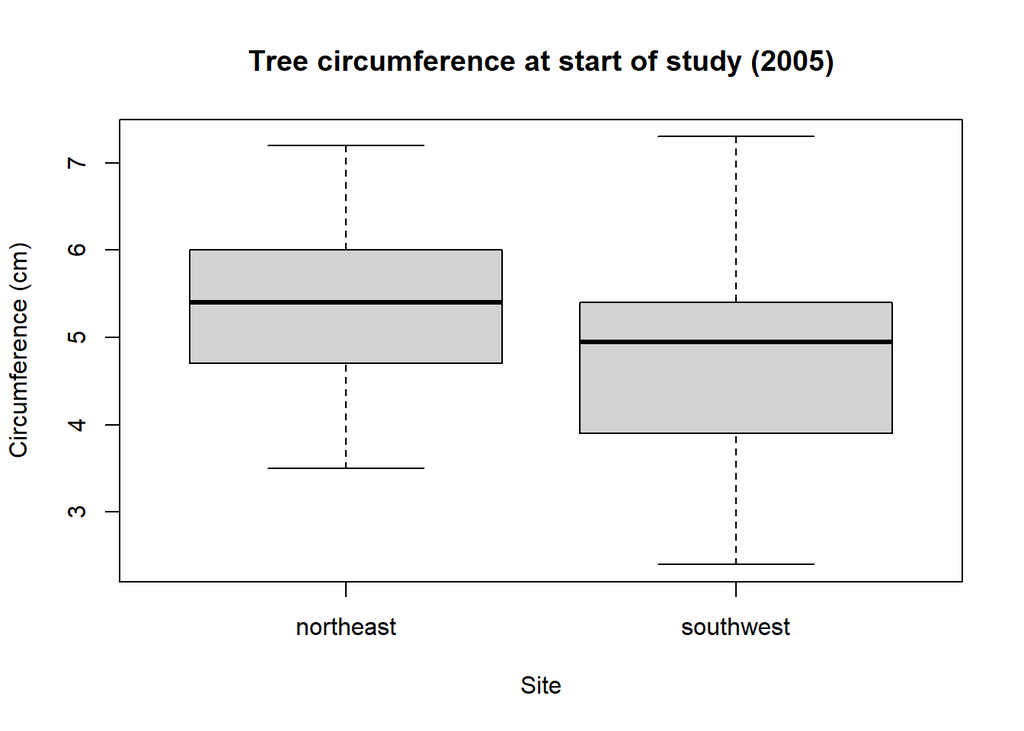

The following two boxplots show the tree circumference at the end of the study in 2020 at the northeast and southwest sites.

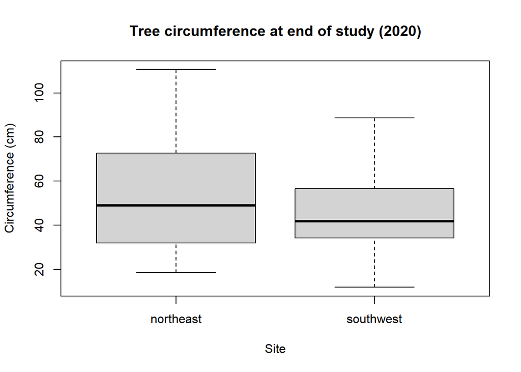

### 9. Calculate the mean growth over the last 10 years at each site.

We will first calculate the total growth between 2010 and 2020 (last 10 years).

We can then calculate the mean for each site using **tapply**.

```
## northeast southwest
##     42.94     35.49
```

The mean growth over the last 10 years at the northeast site was 42.94cm which was greater than the southwest site which had a mean growth of 35.49cm.

### 10. Use the t.test to estimate the p-value that the 10 year growth is different at the two sites.

Using a two-sample t-test, we evaluate the 10 year growth difference to get a p-value of:

```
## [1] 0.06229256
```

As p = 0.06 which is greater than 0.05, the growth difference is **not** considered to be significantly different between the two sites.